# Suboptimal macronutrient ratios promote cannibalism in a generalist herbivore (Trichoplusia ni) - Randall - Ecological Entomology - Wiley Online Library

## MATERIALS AND METHODS

To investigate the effects of altered macronutrient ratios on cannibalistic behaviour and mortality, we conducted a two-choice diet preference bioassay at Michigan State University's Kellogg Biological Station, Hickory Corners, MI, USA. We used a common generalist agricultural pest, *Trichoplusia ni* (Lepidoptera: Noctuidae; Shorey et al., 1962), as our focal species. We purchased eggs from an insectary (Benzon Research, Carlisle, PA) and reared larvae in the laboratory on a general noctuid diet (Southland Products Inc., Lake Village, AR) until they reached second instar. After reaching the second instar, we moved the caterpillars to experimental treatments (detailed below) in a growth chamber set to 26°C and an L:D photoperiod of 16:8 h (Scott et al., 2017).

We quantified cannibalism by performing daily censuses for signs of cannibalism and mortality until adulthood, which allowed us to measure the rate of cannibalism throughout the life stages of *T. ni*. Larvae leave distinct chewing damage when they cannibalise (Figure 1), and this damage lets us differentiate cannibalism from other mortality factors, such as poor nutrition or disease. We closely monitored each cup for each day and distinguished features of cannibalism from other signs of mortality. If there were visual signs of bite marks and chewing damage on the caterpillar or the caterpillar had been ingested, then this was counted as cannibalism. If there was a dead conspecific in the cup without signs of chew damage on the corpse from the caterpillar that was still alive in the cup, it was recorded as a non-cannibalistic mortality.

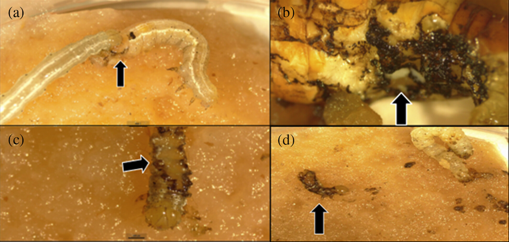

**FIGURE 1**

Examples of *T. ni* cannibalistic feeding damage. *T. ni* actively feeding on a conspecific while on an unbalanced diet treatment (a). Cannibalism of a *T. ni* pupae by a smaller conspecific (b). Dark coloured border of necrotized tissue surrounding the feeding damage indicating cannibalism, with an empty inner body cavity (c). Leftover cavity of a cannibalised *T. ni*, with dark coloured frass indicating digestion of the attacked larvae by the cannibal conspecific (d).

To verify all cannibalism observations, we examined each cup daily using a stereo microscope, capturing pictures with a digital camera attachment (Leica Microsystems, Wetzlar, Germany) to establish a record of cannibalism (Figure 1). Cannibalism was only recorded after this verification, which was completed immediately after each visual census. When quantifying first instances of cannibalism, there were two potential outcomes in each cup (0 for non-cannibalism, and 1 for cannibalism). In addition, when quantifying caterpillar survival, there were also two outcomes (0 for live caterpillars, and 1 for dead caterpillars). Therefore, we modelled the effects of our three diet treatments on cannibalism and caterpillar survival using binomial generalised linear mixed models (GLMMs) in the lme4 package (Bates et al., 2015) in R. We determined the significance of treatment effects on cannibalism using likelihood ratio tests comparing models with fixed effects to null models without that effect, focusing on when cannibalism rates were highest across the treatments (day 3) and the end of the experiment (day 11). We determined the significance of diet treatment effects on the likelihood of caterpillars being cannibalised during the experiment using Kaplan–Meier estimate curves paired with log-rank tests using the survminer package in R.

## RESULTS

### *How do altered macronutrient ratios affect the prevalence of cannibalism?*

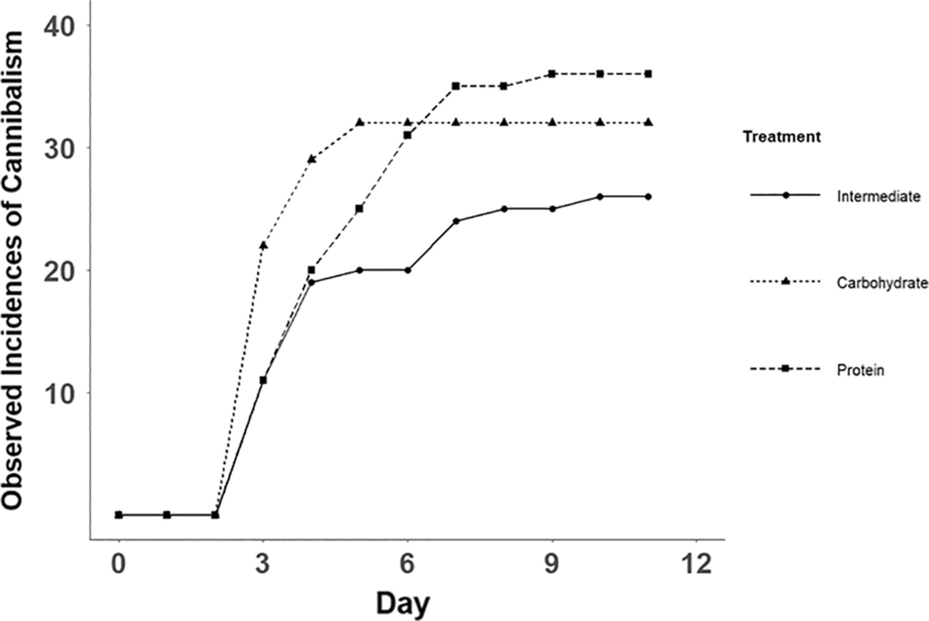

**FIGURE 2**

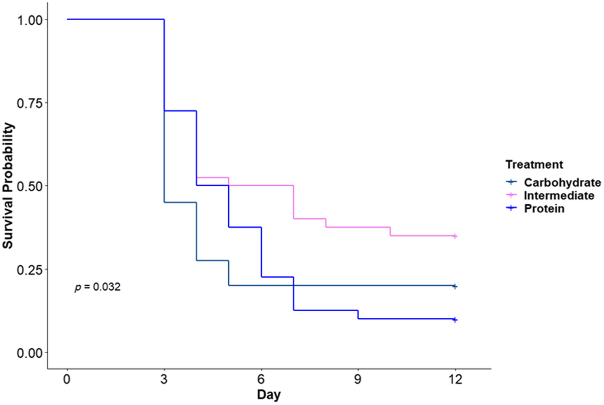

**FIGURE 3**

Kaplan–Meier survival estimates of likelihood of being cannibalised throughout the experiment in each diet treatment: surplus carbohydrate, surplus protein and balanced intermediate diet. Status of caterpillars in each cup was recorded as alive if no cannibalism was detected, and dead on the same day cannibalism was observed and recorded.

### *How do altered macronutrient ratios affect survivorship among cannibals and non-cannibals?*

TABLE 1. Percent cannibal mortality was calculated by dividing the number of cannibals in each treatment by the number of cannibals that died before reaching the pupal stage.

[output not shown]

- *Note*: Percent non-cannibal mortality was calculated by dividing the number of non-cannibals in each treatment by the number of non-cannibals that died before reaching the pupal stage.

## DISCUSSION

We found that unbalanced macronutrient ratios, with either surplus carbohydrates or surplus protein, caused increased rates of cannibalism in *T. ni*, and a higher likelihood of being cannibalised when compared with a balanced macronutrient ratio control diet. Furthermore, overall survival among cannibals was highest in the balanced ratio treatment. This work expands on previous studies that indicated the role of plant chemical defence (Orrock et al., 2017) and nutrient deficiencies (Chapman et al., 1999; Xiao et al., 2010) in causing cannibalism by demonstrating that unbalanced macronutrient ratios of two important macronutrients, proteins and carbohydrates, contribute to increases in cannibalism in plant-chewing herbivores. When diets are severely unbalanced, caterpillars may turn to pre-ingestive mechanisms such as cannibalism to regulate their macronutrient intake. This was true for carbohydrates present in excess, which is not surprising because cannibalism has long been thought of as a way for organisms to increase protein intake. It was, however, surprisingly also true for protein present in excess and carbohydrates in deficient, suggesting that diets composed of macronutrients outside of their optimal balance, regardless of which macronutrient is deficient, encourage behavioural plasticity to cannibalism in insect herbivores.

We found that a surplus diet of carbohydrates led to a rapid, increased cannibalism response in a shorter timeframe by caterpillars, while a surplus protein diet led to a greater overall cannibalism response, but the response was more delayed (Figure 2). Caterpillars can, therefore, not afford to put off selecting protein in their diet and, therefore, long-term growth (Karasov & Rio, 2007; Simpson & Raubenheimer, 2012; Woods, 1999) until later in development. In comparison, they are seemingly able to do so for carbohydrates, therefore putting off short-term growth (Behmer, 2009; Le Gall & Behmer, 2014; Simpson & Raubenheimer, 2012). This delayed response could indicate that in the field, when caterpillars face an unbalanced ratio of protein relative to carbohydrates, caterpillars are more likely to turn to cannibalism earlier and select for long-term growth. In addition, we found that caterpillars on unbalanced macronutrient ratio diets had a higher likelihood of being cannibalised when compared with caterpillars on a balanced, intermediate macronutrient ratio diet (Figure 3). Therefore, caterpillars on nutritionally balanced plants demonstrate a reduced need to turn to cannibalism as a compensatory feeding strategy to balance their macronutrient intake. This indicates that balanced macronutrient ratio diets reduce the relative risk of being a victim of cannibalism and increase survival, while unbalanced macronutrient diets increase risk and reduce survival.

In the field on a plant with a poor, unbalanced macronutrient ratio, a caterpillar, rather than cannibalise, could move to a neighbouring host plant with a higher relative concentration of macronutrients to compensate for this deficiency. A caterpillar could also move host plants to reduce the elevated risks associated with being a potential victim of cannibalism on a plant with a poor host. Movement, however, also involves significant costs and risks. For example, acclimating to a novel host requires herbivores to modify their digestive phenotype (gut size, cytochrome P450 and other detoxification enzymes) in response to varying levels of host-plant chemicals and nutrients. This mandatory acclimation to a different host plant takes both time and resources (Schoonhoven & Meerman, 1978; Schultz, 1983; Wetzel & Thaler, 2016) and incurs an increased risk of predation due to increased time having to be spent by the caterpillar on compensatory feeding, increasing time exposed to predators, and less on counter-predator measures such as hiding and increasing development time (Bernays, 1997; Wetzel & Thaler, 2016). Therefore, to avoid risks associated with host-plant migration, compensate for poor nutritional quality, and maintain ideal development periods, caterpillars could instead remain on their host plant. For example, they may cannibalise if they encounter conspecifics or avoid mortality risk associated with wounds sustained when attacked by conspecifics and competition over poor quality leaves by moving to a new leaf or area of the host plant with lower caterpillar density. In addition, caterpillars on nutrient-poor hosts may also face increased host-plant defences, which can alter a caterpillar's ability to engage in compensatory feeding (Awmack & Leather, 2002; Lavoie & Oberhauser, 2004; Malcolm et al., 1989). Therefore, caterpillars on nutrient-poor, low-quality hosts may exhibit less energy and reduced ability to turn to cannibalism, a type of compensatory feeding, than caterpillars on nutrient-rich, higher quality hosts. These dynamics illustrate the potential role of cannibalism in mediating caterpillar movement and host preference in field settings.

Our results also demonstrated that survival among cannibals in both the surplus carbohydrate treatment and the surplus protein treatment was lower than in the treatment with optimum macronutrient levels. These results align with previous arguments that cannibalism might not be a viable, long-term survival strategy due to high mortality among cannibals (Chapman et al., 1999, 2000; Lynch, 1984; Simpson et al., 2018). Low survival in all experimental treatments (Table 1) could be explained partially by physical injuries such as bite marks to cannibals, likely due to the attacked caterpillar fighting back against the attacking cannibal before it was ultimately consumed. These physical injuries were characterised by open wounds from chewing, surrounded by a ring of dark, necrotized tissue (Figure 1). This damage was spotted among attacked caterpillars who had sustained physical injuries. However, within several days after open wounds were noted, each caterpillar, both cannibal and non-cannibals alike, with an open wound died, resulting from the effects of loss of haemolymph and tissue damage leading to an inability to moult or pupate. In addition, cannibalism was observed in instances in which one caterpillar pupated before the other caterpillar and was then cannibalised by the caterpillar who had not pupated (Figure 1b; B. Randall, personal observations). This may have been due to poor nutrition from the treatments delaying moulting in some caterpillars, leading one caterpillar to become an instar larger than the other. In turn, caterpillars that pupated earlier were at greater risk of being cannibalised due to reduced mobility and ability to defend themselves from an attacker who had yet to pupate. Therefore, the consequences for entire populations extend beyond the mortality of the victims of cannibalism as caterpillars and include victims of caterpillars at different growth stages.

Our results indicate that the acquired macronutrients from cannibalism did not adequately compensate for unbalanced macronutrient intake. As the paired conspecific was also feeding on the same macronutrient-deficient diet treatment, the attacked caterpillar may not have contained enough of that deficient macronutrient to aid in the survival of the cannibal (Despland & Noseworthy, 2006; Raubenheimer, 1992; Raubenheimer & Simpson, 2003; Simpson et al., 1993). Therefore, in our study, the strategy to cannibalise was indicative of an attempt by the caterpillar to regulate macronutrient intake but was largely unsuccessful (Despland & Noseworthy, 2006), although survival levels among cannibals given unbalanced diets had marginally better survival than non-cannibals in unbalanced diets. However, in our balanced treatment, non-cannibals had more than double the pre-pupal mortality as cannibals (Table 1). By reducing competition through cannibalism, cannibals increased their survival due to the nutritional benefits of a balanced macronutrient ratio diet, leading to reduced pre-pupal mortality rates. Future work should investigate if cannibals preferentially choose to cannibalise caterpillars with higher levels of the deficient macronutrient that the cannibal is deficient in and if survival increases when compared with cannibalising caterpillars. This could demonstrate that although cannibalism does come with inherent physical risk, there is some benefit to cannibalism in instances of dietary stress if caterpillars can adequately compensate for nutrient deficiencies common for herbivores.

Our results indicated that when macronutrient ratios differ from the optimum ratio of protein and carbohydrates, cannibalism rates increased regardless of which macronutrient, protein or carbohydrate was present in greater quantities. Increasing levels of cannibalism in nutrient-deprived treatments also coincided with low survival probability and low overall levels of survival among cannibals. We suggest that future studies investigate the potential costs and benefits of cannibalism associated with macronutrient compensation or a preference to attack conspecifics fed on diets with higher macronutrient levels. We also suggest future studies that explore the role of unbalanced macronutrient ratios on caterpillar survival in the absence of conspecifics to assess effects of unbalanced macronutrient ratio diets without conspecific competition, as well as in species with high rates of cannibalism, such as fall armyworm (*Spodoptera frugiperda*). These findings offer new information about the physiological mechanisms governing changes in feeding behaviour to cannibalism, contributing to establishing a more comprehensive picture of the ecological and physiological conditions that drive cannibalism behaviour in plant-chewing herbivores.

## AUTHOR CONTRIBUTIONS

**Brendan A. Randall:** Conceptualization; investigation; methodology; validation; formal analysis; project administration; data curation; writing – review and editing; writing – original draft; visualization. **Elizeth Cinto Mejía:** Writing – review and editing; formal analysis; methodology; conceptualization; investigation; funding acquisition; validation; visualization. **Kayleigh C. Hauri:** Funding acquisition; formal analysis; conceptualization; investigation; methodology; validation; visualization; writing – review and editing. **Will Wetzel:** Conceptualization; methodology; writing – review and editing; project administration; supervision; resources; funding acquisition; formal analysis.

## ACKNOWLEDGEMENTS

We thank G. Avalos and E. Mall for help in the lab experiment; L. Zehr for technical support; and Z. Szendrei, J. Orrock and two anonymous reviewers for valuable comments and feedback on the manuscript.

## FUNDING INFORMATION

This research was supported by Agriculture and Food Research Initiative Competitive Grant no. 2018-67013-28065 from the USDA National Institute of Food and Agriculture and a Kellogg Biological Station Maxey Graduate Student Research Fellowship. Additional funding was provided by AgBioResearch, Michigan State University. The Kellogg Biological Station contribution number is 2356.

## CONFLICT OF INTEREST STATEMENT

The authors declare no conflicts of interest.

[figure not shown]